# Analyzing the Impact of Vitamin Supplements on Tooth Growth in Guinea Pigs

Success Moses(msucc2024@gmail.com)

2024-09-01

```r
library(ggplot2)
library(dplyr)
library(knitr)
library(kableExtra)
```

### Overview

In this article, I analyze the **ToothGrowth** dataset in R to explore the effects of vitamin C supplements on tooth growth in guinea pigs. The goal is to examine the key variables, perform exploratory data analysis, and apply statistical inference techniques to determine whether supplement type and dosage have a significant impact on tooth growth. Through this analysis, I aim to uncover meaningful insights and draw reasonable conclusions from the data.

### The data

```r
data("ToothGrowth")
data = ToothGrowth

kable(head(data, 10),
      caption = "First 10 rows of ToothGrowth dataset",
      format='html',
      align = 'c'
      ) %>%
kable_styling(full_width = FALSE, position = "center") %>%
  column_spec(1:3, width = "5cm")  # Set column width
```

First 10 rows of ToothGrowth dataset

| len | supp | dose |
| --- | --- | --- |
| 4.2 | VC | 0.5 |
| 11.5 | VC | 0.5 |
| 7.3 | VC | 0.5 |
| 5.8 | VC | 0.5 |
| 6.4 | VC | 0.5 |
| 10.0 | VC | 0.5 |
| 11.2 | VC | 0.5 |
| 11.2 | VC | 0.5 |
| 5.2 | VC | 0.5 |
| 7.0 | VC | 0.5 |

The dataset consist of 60 observations in 3 columns. The ToothGrowth dataset contains data from an experiment on the effect of vitamin C on tooth growth in guinea pigs. The dataset has three variables:

`len`: This represents the length of the odontoblasts (cells responsible for tooth growth) in the guinea pigs. It is the response variable and is measured in millimeters.

`supp`: This represents the type of supplement given to the guinea pigs. There are two levels: `VC`: Vitamin C supplement. `OJ`: Orange juice supplement.

`dose`: This represents the dosage of the supplement provided to the guinea pigs. It is a numeric variable with three possible values: 0.5, 1, and 2 (measured in milligrams per day).

### Exploratory Data Analysis

The table below shows the number of observations in the dataset for each supplement type—Orange Juice (OJ) and Vitamin C (VC)—providing insight into the sample size associated with each treatment group.”

```r
# Create a frequency table and convert it to a data frame
x <- table(data$supp) %>% as.data.frame()
names(x) <- c('Supplement', 'Frequency')

# Generate the table using kable
kable(x,
      caption = "Distribution of Observations by Supplement Type (OJ vs. VC)",
      format = 'html',
      align = 'c'
      ) %>%
  kable_styling(full_width = FALSE, position = "center") %>%
  column_spec(1, width = "5cm") %>%  # Set width for the first column (supplement type)
  column_spec(2, width = "5cm")      # Set width for the second column (count)
```

Distribution of Observations by Supplement Type (OJ vs. VC)

| Supplement | Frequency |
| --- | --- |
| OJ | 30 |
| VC | 30 |

We expect len to increase with dose. Figure below is a box plot of len for each of dose.

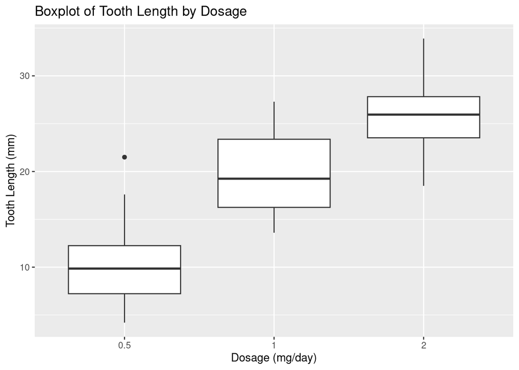

```r
data$dose = as.factor(data$dose)

# Plot 1: Boxplot of tooth length (len) by dose
ggplot(data, aes(factor(dose), len)) +
  geom_boxplot() +
  labs(
    title = "Boxplot of Tooth Length by Dosage",
    x = "Dosage (mg/day)",
    y = "Tooth Length (mm)"
  )
```

Now if we plot, make of similar box plot of len against supp, we see that average tooth growth when supplement 1 is given is greater than the average tooth growth when supplement 2 is given.

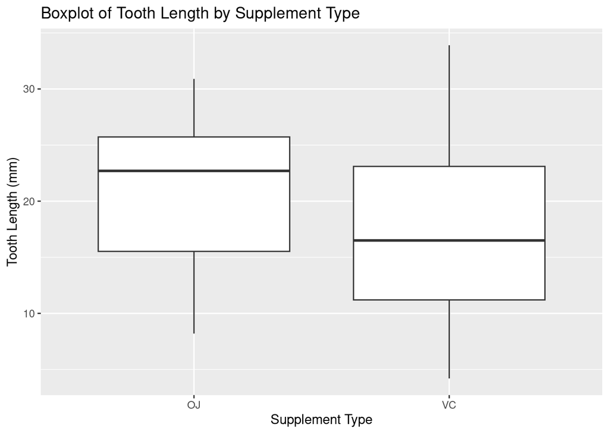

```r
# Plot 2: Boxplot of tooth length (len) by supplement type
ggplot(data, aes(factor(supp), len)) +
  geom_boxplot() +
  labs(
    title = "Boxplot of Tooth Length by Supplement Type",
    x = "Supplement Type",
    y = "Tooth Length (mm)"
  )
```

### Stastical Inference

Of course, this could be due to random chance so I am going to formally test the hypothesis that their averages are the same using a Welch Two Sample t-test at a type one error rate of 5%

```r
ojdata <- dplyr::filter(data, supp=='OJ')
vcdata <- dplyr::filter(data, supp=='VC')
test1 <- t.test(ojdata$len, vcdata$len, paired = FALSE)
test1
```

```
    Welch Two Sample t-test

data:  ojdata$len and vcdata$len
t = 1.9153, df = 55.309, p-value = 0.06063
alternative hypothesis: true difference in means is not equal to 0
95 percent confidence interval:
 -0.1710156  7.5710156
sample estimates:
mean of x mean of y
 20.66333  16.96333
```

In this case, I used an unpaired (independent) t-test since the observations in the different groups are not paired. The p-value of the Welch test is `0.0606345`. Since the p-value is greater than 0.05, we fail to reject the null hypothesis at a 95% significance level. This means **there is insufficient evidence to conclude that the average tooth growth for the group that took the `OJ` supplement is different from the group that took the `VC` supplement**.

Similarly, we can run a Welch t-test for the significance of the observed difference in means between different `dose` levels. Again, we assume the observations are independent.

```r
group1 <- dplyr::filter(data, dose==0.5)
group2 <- dplyr::filter(data, dose==1)
group3 <- dplyr::filter(data, dose==2)

test2 <- t.test(group1$len, group2$len, paired=FALSE)
test3 <- t.test(group2$len, group3$len, paired=FALSE)

test2$p.value < 0.05
test3$p.value < 0.05
```

```
[1] TRUE
[1] TRUE
```

The p-value of both test are below the threshold, hence we **reject** the null hypothesis that the mean are equal and conclude that **dosage increases tooth growth**

### Conclusion

This analysis demonstrates that while the type of supplement (OJ vs. VC) does not appear to have a statistically significant impact on tooth growth, dosage plays a critical role. The results indicate that increasing the dosage of vitamin C supplements significantly increases tooth growth in guinea pigs. This finding could have practical implications for optimizing vitamin supplementation strategies for tooth development in experimental or applied contexts.